# Standardized Qualitative Analysis of Dynamics (SQUAD) R package

[R Markdown](http://rmarkdown.rstudio.com)

During the definition of a regulatory network model it is frequently convenient to start with simple formalisms and then to transit to more refined models. Continuous interpolations of Boolean Regulatory Networks (BRN) are defined so as to preserve dynamical characteristics of discrete model but extending the range of values of the variables. In this tutorial we presented the main features of the SQUAD R package to simulate continuous interpolations of BRN models.

SQUAD package is a useful tool to define, set up and run simulations using continuous interpolations of regulatory network models. It also can perform stationary states search.

*1. Overview of SQUAD R package*

The next figure shows schematically the main features of the SQUAD R package. SQUAD extends the functionallity of the BoolNet R package. BoolNet has integrated an optimized method to find synchronous stable states by using the Dubrova algorithm. By the other hand, in an asynchronous context SQUAD performs an optimized heuristic method using BDD representations and model checking. So, the modeller can start defining a discrete BRN model and choose synchronous or asynchronous efficient methods for stationary states search.

Additionally, if needed the modeler can transit to more refined continuous methods as the SQUAD methodolgy.

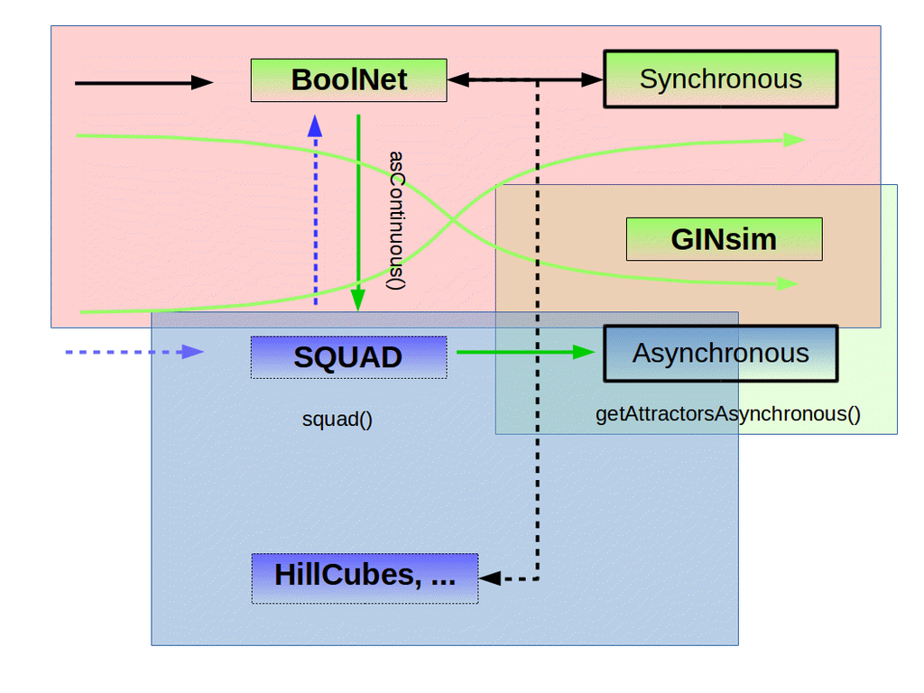

*2. Instaling SQUAD*

Prior to use the SQUAD R package please install the following packages:

- deSolve
- RColorBrewer
- ggthemes
- ggplot2
- BoolNet
- reshape

Some of these packages may require the instalation of devtools and XML libraries. To instal the SQUAD R package please run the following command inside R.

```r
library(devtools)
# temporary loading from github
install_github("caramirezal/SQUAD/SQUAD")
```

```
## Skipping install of 'SQUAD' from a github remote, the SHA1 (72531e9d) has not changed since last install.
##   Use `force = TRUE` to force installation
```

*3. Defining and running a simulation using SQUAD formalism*

*3.1. Starting with a discrete BRN model*

As mentioned aboved, BRN are parameters free simple models which emphasizes in the study of the dynamics driven by the combinatory of values of the regulators that determines the levels of activations of the nodes in the network. In practice, it is usually convenient to start with such a simple approach and then transit to more complex formalism if needed. SQUAD method can be used in combination with BoolNet to acomplish this task as follows.

To exemplify a BRN model we start with a random model defined with the [BoolNet R Package](https://academic.oup.com/bioinformatics/article/26/10/1378/193238/BoolNet-an-R-package-for-generation-reconstruction).

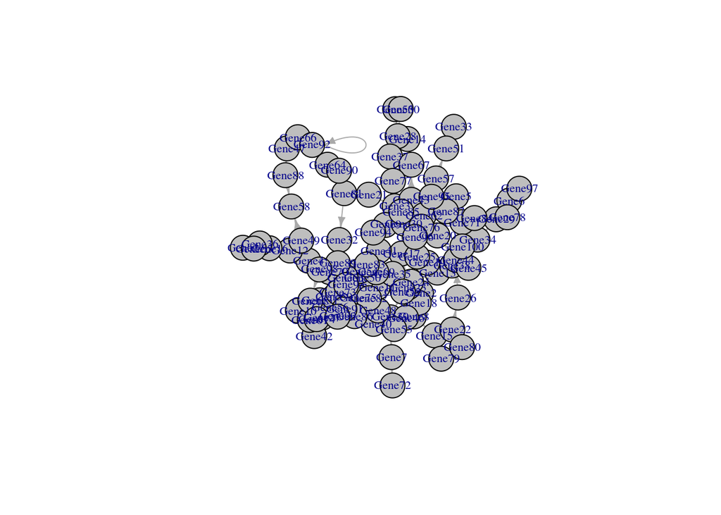

```r
library(BoolNet)
library(deSolve)
library(RColorBrewer)
library(ggthemes)
library(ggplot2)
library(reshape)
library(SQUAD)
# loading the Boolean model
net.bool <- generateRandomNKNetwork(n=100,k=5,topology = "scale_free",simplify = T)
# plotting the BRN topology
plotNetworkWiring(net.bool)
```

The BRN model has been initialized with 100 nodes.

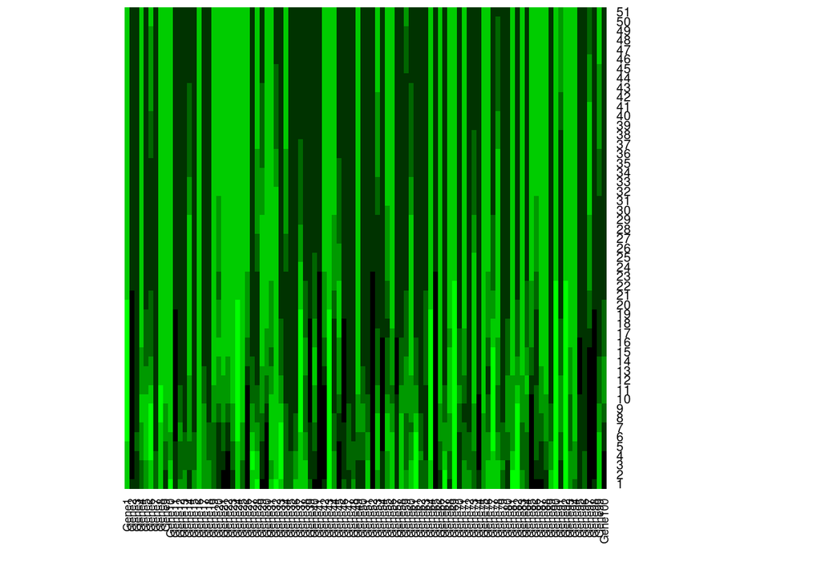

```r
# transforming the model to a continuous formalism using SQUAD
net.squad <- asContinuous(net.bool)

# simulating a network trajectory
squad(net.squad,timePeriod = 5,lengthInterval = 0.1)
```

The figure shows a single trajectory of the network. Parameters are fixed to default parameters which are $beta = 1$ and $gamma = 50$ in every ODE function.

*Calculation of stady states*

We exemplify here the calculation of staeady states (SS) attractors calculated in the asynchronous updating regimen. To perform SS in a synchronous context, please see [BoolNet](https://cran.r-project.org/web/packages/BoolNet/index.html) documentation.

```r
getAttractorsAsynchronous(net.bool)
```

```
##         Attr.1
## Gene1        0
## Gene2        1
## Gene3        0
## Gene4        1
## Gene5        1
## Gene6        0
## Gene7        1
## Gene8        1
## Gene9        1
## Gene10       1
## Gene11       1
## Gene12       1
## Gene13       1
## Gene14       1
## Gene15       0
## Gene16       0
## Gene17       0
## Gene18       1
## Gene19       0
## Gene20       1
## Gene21       1
## Gene22       1
## Gene23       1
## Gene24       0
## Gene25       0
## Gene26       1
## Gene27       0
## Gene28       1
## Gene29       1
## Gene30       1
## Gene31       0
## Gene32       0
## Gene33       1
## Gene34       0
## Gene35       1
## Gene36       1
## Gene37       0
## Gene38       1
## Gene39       1
```

[output cut: 46 more lines]

```
## Gene86       1
## Gene87       0
## Gene88       1
## Gene89       1
## Gene90       1
## Gene91       1
## Gene92       1
## Gene93       1
## Gene94       0
## Gene95       1
## Gene96       1
## Gene97       1
## Gene98       1
## Gene99       1
## Gene100      1
```

As can be seen the method can be used to find SS from large networks in a very efficient way.